# Lesson 110 · Q3 checkpoint: a temporal GNN you can defend

## Follow the computation

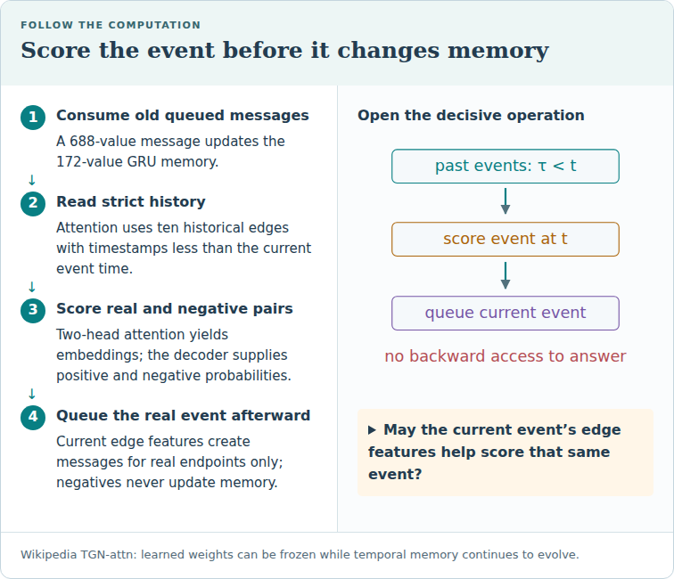

Wikipedia TGN-attn: learned weights can be frozen while temporal memory continues to evolve.

**Trace question:** May the current event’s edge features help score that same event?

**Trace answer:** Not in this declared TGN path. They enter the message queue after scoring.

Solution · Three live TODOs, real-data CHECKs, visible model and trainer, written EXIT. Author evidence does not establish learner mastery.

```python
# @colab-bootstrap — standalone implementation, no course-package imports.
import sys,importlib.metadata
print('Python',sys.version.split()[0])
print({name:importlib.metadata.version(name) for name in ['torch','numpy','pandas','scikit-learn']})
```

```
Python 3.12.3
{'torch': '2.13.0+cpu', 'numpy': '2.5.0', 'pandas': '3.0.3', 'scikit-learn': '1.9.0'}
```

## Runtime and data

The full GPU author runs pin Python 3.12, torch 2.8.0, NumPy 2.2.6, pandas 2.3.2 and scikit-learn 1.7.1. Install the linked `requirements-l110-runtime.txt` in a separate environment to match those libraries. The local CPU notebook records its installed versions and is a separate teaching execution. If needed, `%pip install torch numpy pandas scikit-learn` supplies a convenient unpinned teaching runtime; restart after installation. First data access downloads about 534 MiB and verifies its SHA-256. Allow at least 2 GiB RAM. Live Colab is NOT_CHECKED. The long-run gate is off by default; it can take hours and should use an explicit external runtime/cost limit.

From Lesson 109 to this lesson

The clock, sampler and model are now defined. The checkpoint must preserve the predictor that actually produced the selected validation score.

**Quick prerequisite reminder**

Parameters are learned shared weights. Temporal state includes memories, clocks and pending messages. A checkpoint is a saved state; restoring only some of it can change predictions.

One skill: defend a trained temporal GNN from data cutoffs to restored state

A good test score is only useful if the predictor could have known its inputs. **Your Q3 checkpoint is to train a temporal graph network, reconstruct its evaluation, and demonstrate that changing the future cannot change an earlier prediction.** You will submit working code and a short defense, rather than declare mastery because a notebook ran.

[L102](https://avistian.github.io/relational/lessons/0102-temporal-graph-networks.html) supplied the TGN computation. [L104](https://avistian.github.io/relational/lessons/0104-information-leakage-in-time.html) tested information access. [L108](https://avistian.github.io/relational/lessons/0108-temporal-neighbor-sampling.html) examined strict-past neighborhoods, and [L109](https://avistian.github.io/relational/lessons/0109-database-timestamp-contracts.html) separated event dates from actual availability. Here those pieces become one executable contract. This serves our mission: results on a relational graph must survive the same scrutiny as features built from database history.

**Primary reading:** [Rossi et al., Temporal Graph Networks, v3](https://arxiv.org/abs/2006.10637v3), §3 for memory/messages/embeddings and Table 2 for the selected Wikipedia results. Read the [released trainer](https://github.com/twitter-research/tgn/blob/e38cdf85998c6ca077167610dc4e769a688efa95/train_self_supervised.py) alongside the paper. The two are distinct evidence sources: prose defines the method; executable code resolves many protocol details.

## 2 · Model architecture: score the event before learning from it

> **In plain terms.** The network predicts whether a user will edit a page using earlier interactions. Only after making the prediction may it remember the edit that actually happened.

An interaction is a tuple `(user, page, timestamp, event_features)`. This dataset provides 172 numeric features per interaction. A node is a user or page with a stable integer identifier. Node features are zero vectors in this experiment, so identity and history carry the relational information. **Memory** is a 172-number vector stored for each node. Its entries are learned summaries, not named factual fields.

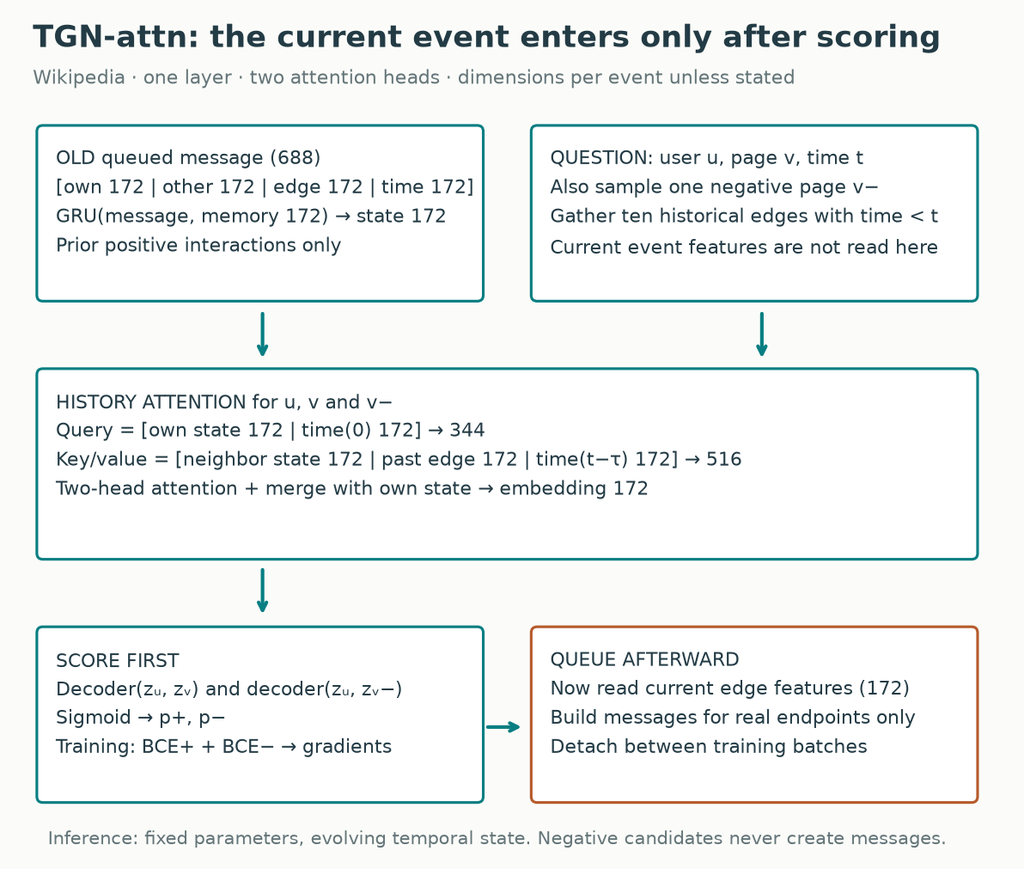

Complete Wikipedia TGN-attn path: 688-number old message → GRU state → strict history attention → score; current features enter only after scoring.

**Diagram trace.** Find the score-before-update boundary. Which current-event features are unavailable until after scoring? On a narrow screen, scroll the figure sideways.

**First consume old messages.** A queued message contains the two endpoint memories, the interaction features and an elapsed-time encoding: 172 + 172 + 172 + 172 = 688 numbers. A gated recurrent unit (GRU) combines that message with the previous 172-number memory. A GRU learns how much old state to retain and how much new information to write. The latest queued message per node is used here. See the paper's message/update equations and the [released memory updater](https://github.com/twitter-research/tgn/blob/e38cdf85998c6ca077167610dc4e769a688efa95/modules/memory_updater.py).

**Then gather history.** For each endpoint and sampled negative page, retrieve the latest ten interactions strictly earlier than the question. The cosine time encoder maps elapsed seconds into 172 learned periodic coordinates. In the diagram, `t` is the query time and `τ` is a historical interaction time, so `t−τ` is its age. A query joins the node state and a zero-elapsed encoding, giving 344 coordinates. Each attention key/value joins a neighbor state, historical edge features and its elapsed encoding, giving 516 coordinates. Two attention heads weight those historical inputs. A merge network returns a 172-number embedding for each endpoint. Padding stands for absent history and must not become a real neighbor.

**Then score candidates.** A small neural decoder maps two endpoint embeddings to a scalar logit. A sigmoid converts that number into a score between zero and one. The training loss rewards the observed user–page pair and penalizes one uniformly sampled page. Binary cross-entropy is `−y log(p) − (1−y) log(1−p)`; `y=1` means an observed pair and `y=0` means a sampled pair. The optimizer changes parameters using gradients of this loss. Gradients pass through the current GRU update and attention computation; detaching between batches cuts the older computation graph. During evaluation, parameters stay fixed while node memory and queued observations still evolve. A sampled pair is not proof that the user will never edit that page; it defines the benchmark's prediction question.

**Finally queue the observed interaction.** Current edge features enter the message path after scoring, not the embedding used for their own score. The saved message is consumed at a later batch. The negative candidate creates no observed interaction and therefore creates no new message. The [released TGN implementation](https://github.com/twitter-research/tgn/blob/e38cdf85998c6ca077167610dc4e769a688efa95/model/tgn.py) makes this order concrete.

A batch is a group scored from one pre-batch state. Earlier events inside that batch do not update later predictions in the same batch. This is delayed observation, not future access. It means batch size is part of the temporal protocol, not only a performance setting.

## 3 · Write down what “clean” means

For a question at time `q`, history in this lesson requires both `event_time < q` and `observed_time < q`. **Event time** is when something happened. **Observed time** is when the predictor could use it. We use strict comparisons because the question asks about the state before a timestamp group; another application can choose an inclusive convention only if its ordering contract supports it.

Implement `legal_history` in the live TODO below.

The Wikipedia release lacks actual ingestion histories. Our measured runs therefore assume `observed_time = event_time`. Late-arrival fixtures exercise the two-clock rule separately. The paper experiment cannot certify an unrecorded production ingestion history.

| Boundary | Frozen choice | What to inspect |
| --- | --- | --- |
| Time split | 70% and 85% timestamp quantiles | Complete event ID arrays, not a random row split |
| Held-out nodes | 922 sampled nodes withheld from training | Neither endpoint may enter the training population |
| Training | 81,029 events | Chronological order, training-only adjacency |
| Validation / test | 23,621 events each | Validation selects; test reports once per selected checkpoint |
| New-node validation / test | 12,016 / 11,715 events | At least one endpoint unseen in training |
| Negative candidates | Released destination pools and seeded random streams | Preserve pools, collisions and unused source draws |
| Visibility | Strict-past adjacency; release event-time assumption | Future indexing is acceptable only if retrieval excludes future records |

The complete stream has 157,474 interactions. Withheld-node filtering makes the training population smaller than 70% of that count. Evaluation uses the full adjacency index, which can restore historical context involving held-out nodes. “Unseen during fitting” does not mean “forbidden from all evaluation history.” This is the released benchmark contract; state that distinction when reporting inductive performance.

**A database callback.** Link prediction here scores an interaction before observing it. It is not L109's future-window supervised target. For a future-window target, fitting also requires that its outcome window and arrival/completeness conditions have matured. Do not transplant the Wikipedia event schedule into a database prediction task without writing that label contract.

## 4 · A checkpoint is more than a weight file

> **In plain terms.** Loading the right recipe with the wrong remembered history gives a different predictor.

Suppose validation selects epoch 12, but training stops at epoch 17. An **epoch** is one pass over the training events. **Early stopping** ends optimization after validation fails to improve for five epochs. The released trainer saves learned parameters and registered buffers in `state_dict`. Its queued messages live in a separate Python dictionary. Restoring the selected `state_dict` leaves the stopping epoch's queue in place.

This is a state-consistency defect, not by itself evidence of future-test labels leaking. Both queues can come from pre-test observations. Yet the predictor combines components produced by different weights. You cannot defend it as the single selected validation state.

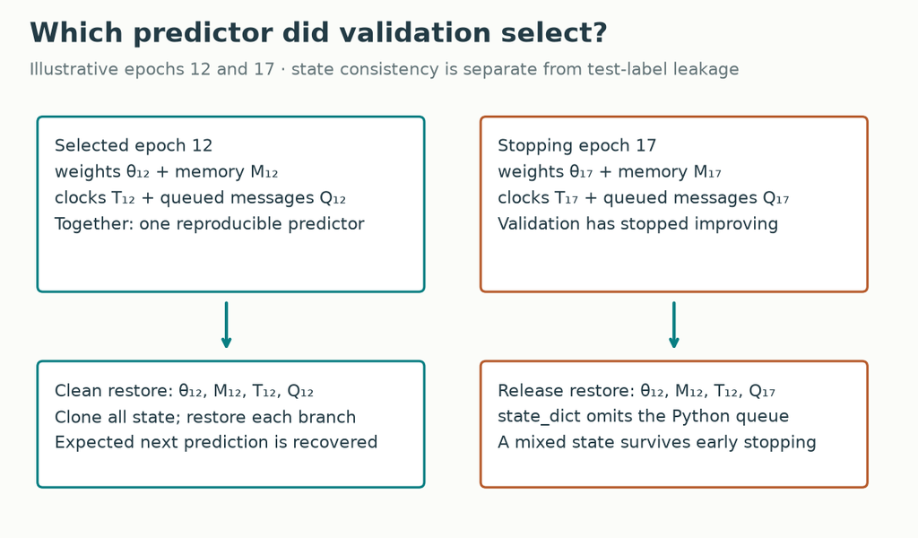

Illustrative selected epoch 12 and stopping epoch 17: the release can combine selected weights/memory/clocks with stopping-epoch queued messages.

The clean-arm restore is small because the important work is defining the complete state:

Implement `restore_checkpoint` in the live TODO below.

The restore first checks that every learned weight and required buffer is present, and rejects unknown keys. Dataset feature buffers may be omitted because `capture_checkpoint` deliberately supplies them from the authenticated input; that exception must not permit missing learned weights. The snapshot contains memory, last-update clocks and cloned queued messages. Cloning prevents later evaluation from silently changing the saved object. Each test branch restores the same selected post-validation snapshot, so running the all-event branch cannot contaminate the new-node branch.

**Watch the missing queue change a real prediction.** In a small four-dimensional instance of this visible TGN, warm the state with interactions `(1,3)` at time 1 and `(1,4)` at time 3. Save weights, memory, clocks and pending messages. Now score `(2,3)` at time 4, with page 4 as the negative candidate. Dropout is zero and every branch uses identical weights, features and sampled history.

| Restored state | Positive / negative score |
| --- | --- |
| Complete checkpoint | 0.396784 / 0.397132 |
| Same state, empty queue | 0.396152 / 0.398773 |
| Complete checkpoint again | 0.396784 / 0.397132 |

The missing queue contains old observations waiting for the GRU. Removing it changes the candidate memories and therefore the scores, even though no parameter changed. Complete restoration recovers the original probabilities **exactly before rounding**. These synthetic scores test state identity; their magnitude is not a benchmark accuracy claim. The released model’s separate message dictionary explains why a weight-file check alone misses this failure.

**Debugging exercise:** a test asserts only that restored parameters equal the saved parameters. Would it reject the empty-queue branch? Add a behavioral check using the next fixed event and negative candidate, then run it twice from independently restored state.

**What the behavioral check must establish**

The parameter-only test passes both branches. The next positive and negative probabilities must both match the saved reference, and the saved checkpoint itself must remain unchanged after either replay. Restore cloned temporal state before each branch; do not let the first branch consume the second branch’s pending messages.

**Prediction replay versus optimization resume.** Our saved artifacts support replaying evaluation. They are not full mid-epoch optimizer resumes: optimizer moments, random-generator state and exact stream position would also be necessary. Completed fits are durable artifacts; partially completed fits do not count as completed seeds.

## 5 · Equal timestamps expose a second hidden state boundary

Consider event times `[1, 2, 2, 2, 3, 4]` and nominal batch size 2. Ordinary slicing produces `[1,2] | [2,2] | [3,4]`. The first batch can queue a time-2 message that the second batch consumes while answering time-2 questions. A strict-past neighborhood filter does not repair this memory path.

The clean batcher extends a batch through its final timestamp group: `[1,2,2,2] | [3,4]`. The size limit is soft. Every previous batch now ends strictly before the next begins. Oversized timestamp groups consume more memory, so inspect their maximum size before scaling to another dataset.

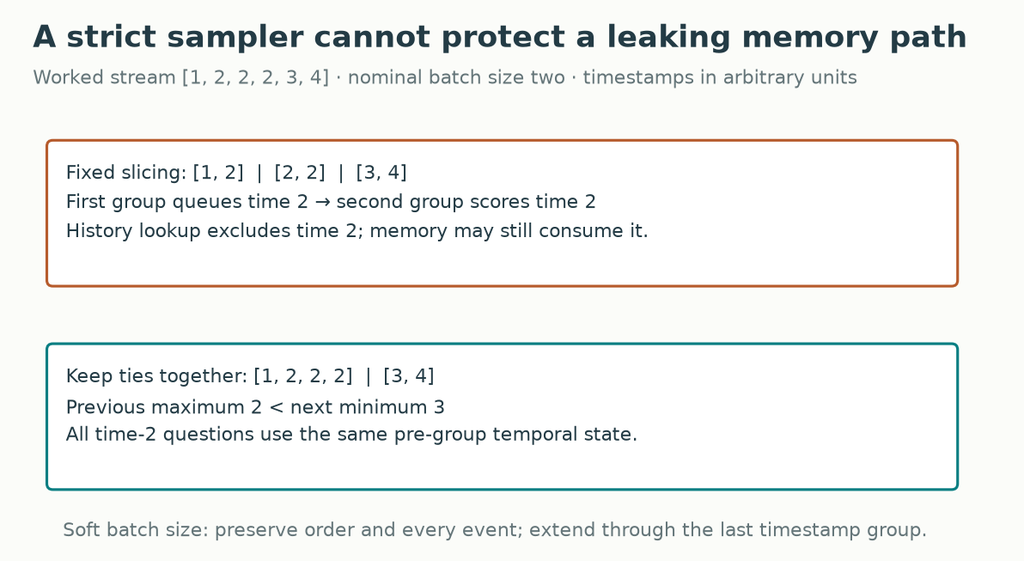

Worked timestamp stream: fixed size-two slicing crosses a time-2 boundary; extending the batch preserves strict-past memory.

Implement `strict_batches` in the live TODO below.

**Predict:** partition the six-event stream at sizes 1, 2 and 3, with and without keeping ties together.

**Full-data boundary census.** This counts boundaries at which equal-time memory could cross; it does not count affected predictions.

| Population | Events | Fixed-slice tied boundaries | Clean tied boundaries | Largest clean batch |
| --- | --- | --- | --- | --- |
| train | 81,029 | 9 | 0 | 201 |
| val | 23,621 | 4 | 0 | 201 |
| test | 23,621 | 4 | 0 | 201 |
| new_val | 12,016 | 1 | 0 | 201 |
| new_test | 11,715 | 0 | 0 | 200 |

**Worked answer, including a no-JavaScript fallback**

At size 2, fixed slices cross one equal-time boundary. Extending the first slice through all three time-2 events gives two groups and zero tied boundaries. A weights-only restore still fails even with these clean groups: batching and checkpoint consistency are separate requirements. Actual late arrivals still require observed timestamps; neither change creates missing arrival evidence.

The clean arm also always restores its best validation epoch when the maximum epoch count is reached. The release uses the final epoch in that situation. These are three declared protocol differences: complete state restoration, tie-safe batching, and consistent best-validation selection. The comparison tests that combined policy. It does not isolate a causal accuracy effect of any one repair.

## 6 · Reproduce first, then interpret the intervention

**Predict before results:** must consistent checkpoint restoration improve AP? Commit your reason before reading.

**Held fixed:** full Wikipedia input, model architecture, features, optimizer, maximum 50 epochs, patience 5, nominal batch size 200, learning rate 0.0001, dropout 0.1, ten explicit seeds and released split/candidate-pool definitions. **Varied:** the three clean-state policies above. Changes in grouping alter random-number consumption and optimization trajectories, even for the same initialization seed. Seed pairing helps compare the two systems; it does not imply identical negative arrays throughout training or evaluation.

**Published lane:** fresh release-compatible training targets the two TGN-attn Wikipedia Table 2 AP cells: 98.46% and 97.81%. The numerical criterion is an absolute mean gap at most 0.5 percentage point, fixed before the new runs. A percentage point is an absolute difference between percentages: 98.46% to 98.96% is +0.50 percentage point. This criterion is a descriptive comparison, not a statistical equivalence test. See [the paper](https://arxiv.org/abs/2006.10637v3) and [the exact reproduction contract](https://avistian.github.io/relational/labs/l110-reproduction.md).

**Course lane:** ten fresh clean-state fits. No published target is assigned to this changed protocol. A cleaner contract may increase, decrease or leave the score unchanged. The reason to repair the contract is that it can be defended, not that it maximizes the reported number.

**Average precision (AP)** summarizes positive retrieval as the score threshold changes. The release calculates AP separately within each scoring batch, then takes an equally weighted mean of those batch values. **Pooled AP** instead ranks all predictions together. These are different metrics. A short final batch gets the same batch-mean weight as a full batch. Because the clean arm changes batching, we report both metrics and expose batch IDs in the saved predictions. Pooled results remain conditional on the actual candidates drawn by that arm.

**Work a tiny metric example.** Batch A scores its positive 0.9 and negative 0.8. Batch B scores its positive 0.2 and negative 0.1. Each batch ranks its positive first, so each AP is 1 and their mean is 1. Pooling gives the label order positive, negative, positive, negative. With no score ties, AP is the mean precision at positive ranks: `(1 + 2/3) / 2 = 5/6`, about 83.33%. Both calculations are correct; they answer differently aggregated questions. Our independent evaluator also handles tied scores by grouping equal thresholds.

**Author-reference evidence, separate from your current notebook output.**

| Protocol | Population | Batch AP mean | Seed SD | Pooled AP mean | Paper comparison |
| --- | --- | --- | --- | --- | --- |
| release | all | 98.5123% | 0.0679 pp | 98.5361% | CLOSE |
| release | new | 97.8295% | 0.0861 pp | 97.8606% | CLOSE |
| clean | all | 98.5234% | 0.0826 pp | 98.5467% | COURSE_INTERVENTION |
| clean | new | 97.7986% | 0.0787 pp | 97.8343% | COURSE_INTERVENTION |

Execution: **COMPLETE**; 10 complete seed pairs. Independently reconstructed 706,720 positive event evaluations plus one sampled negative per event. The clean-arm changes are course evidence, not a second paper reproduction.

Clean minus release, all: batch AP +0.0110 pp (paired seed SD 0.1017); pooled AP +0.0106 pp. Clean minus release, new: batch AP -0.0309 pp (paired seed SD 0.0982); pooled AP -0.0263 pp.

Completed-call resource estimate including the pilot: **USD4.6912**. Startup/build/storage overhead is not itemized; the aggregate plan remains USD10. Full-paper parity remains NOT_ESTABLISHED.

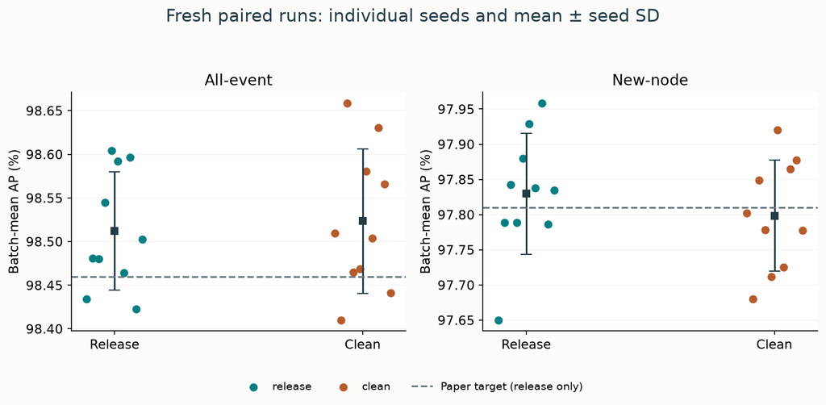

Author-reference full-data runs. Individual seeds and mean ± sample seed SD; published targets apply to the release arm only.

Read each seed as an initialization on one fixed data split. The displayed standard deviation is sample standard deviation across seeds, measured in percentage points. It does not measure uncertainty across different databases or independent time splits.

> **Scope check.** A complete named Wikipedia reproduction is not reproduction of the entire paper. Reddit, Twitter, dynamic node classification, competitor models and the ablation suite remain outside this lesson. Modern libraries and explicit independent seeds differ from the historical environment and original continuously consumed random stream. Historical identity remains INCOMPARABLE; full-paper reproduction remains NOT_ESTABLISHED. Earlier L102 evidence is context, not a substitute for these fresh runs.

## 7 · Make the audit capable of catching a failure

A useful audit changes something the predictor is forbidden to know and asks whether an earlier prediction changes. A passing score or a timestamp assertion at only one layer cannot substitute for that test. In the six-event fixed-weight witness, changing a time-2 feature shifts a later time-2 score by about 0.1083 under fixed slicing. Grouping ties makes all time-2 scores exactly invariant, while time-3/4 predictions still respond. That is a synthetic correctness witness, not an accuracy result.

| Test | Intervention | Required outcome |
| --- | --- | --- |
| Current-event exclusion | Change the feature vector of the event being scored | Its score remains identical before the event is observed |
| Future exclusion | Change a strictly later edge feature | The earlier score remains identical |
| Complete-state recovery | Advance the model, then restore an earlier checkpoint | Recover exactly the saved next prediction |
| Branch isolation | Restore the selected state before each test population | Evaluation order cannot accumulate extra branch history |
| Timestamp boundary | Force a tied group across a nominal batch boundary | Clean batching keeps the group together |
| Availability | Date an event early but deliver it late | Exclude it from earlier legal history |

The repository suite rejects five deliberate faults; the notebook also rejects a broken solution for each of its three live tasks. We also compare the visible encoder's probabilities, gradients and state with the pinned original source; independently reconstruct preprocessing and split arrays; and recompute metrics from saved positive and negative probabilities. These checks answer different questions. Agreement with the original code alone cannot reveal a flaw shared with the original code.

The author contract includes exact commands, file identities, runtime/cost accounting and unrun boundaries. If a runtime cutoff ends a fit, the ledger must say INCOMPLETE. A partial trace is not one of ten completed seeds.

## 8 · Your checkpoint submission

Open the [student notebook](https://avistian.github.io/relational/labs/0110-temporal-gnn-checkpoint.ipynb) or its [prepared walkthrough](https://avistian.github.io/relational/labs/html/0110-temporal-gnn-checkpoint.html). The notebook contains the complete readable model and trainer; its default small training exercise is labeled separately from full-data author evidence. The full experiment gate invokes the same visible training implementation on all released populations.

1. **TODO:** implement complete checkpoint restoration. **CHECK:** recover a prediction after the model has advanced and its weights have changed.
2. **TODO:** implement tie-safe batching. **CHECK:** preserve every input event exactly once and reject equal-time boundary leakage.
3. **TODO:** implement two-clock eligibility. **CHECK:** reject late arrivals and strict-time ties, then audit the full real-data batch frontiers under the declared arrival assumption.
4. **RUN:** train, select with validation, restore both evaluation branches, and independently inspect predictions. Compare full reproduction targets only for the release arm.
5. **EXIT:** submit your code, a fresh run report, one failing time-travel counterexample, and a 200–300 word defense of the split, candidates, state restoration and evidence limits.

**Teach back:** explain how legal adjacency can coexist with invalid memory, and distinguish consistency from accuracy.

A strong defense explains why a strict sampler can coexist with leaking memory, why matched paper scores cannot establish actual availability, and why fixing checkpoint consistency does not guarantee a higher AP. Prepared author evidence does not complete your checkpoint: **PENDING_WRITTEN_DEFENSE** remains until your own explanation and code are reviewed.

Tomorrow, reconstruct the four pieces of inference state without notes. Next week, invent a late-arriving event and a tied-timestamp counterexample. These spaced retrieval tasks test retention beyond today's ability to follow the notebook.

The next quarter moves to OGB benchmark reproduction. Carry forward this habit: define the exact prediction question and evaluator before treating a leaderboard number as evidence. Keep the [temporal checkpoint reference](https://avistian.github.io/relational/reference/temporal-gnn-checkpoint.html) nearby. Ask the teaching agent follow-up questions about any unclear computation or submit your EXIT for feedback.

**Carry this forward.** Transfer this protocol discipline to an official static-graph benchmark. [Continue to Lesson 111](https://avistian.github.io/relational/lessons/0111-ogb-benchmark-contract.html).

## Visible implementation

Read each PROVIDED block as the computation it implements. The original Apache-2.0 TGN source is pinned at `e38cdf85998c6ca077167610dc4e769a688efa95`. Only three functions are TODOs; your implementations are used in the actual checks and clean trainer.

### Imports and immutable experiment identities

```python
import copy
import hashlib
import json
import math
import random
import time
import urllib.request
from pathlib import Path

import numpy as np
import pandas as pd
import torch
from torch import nn
from sklearn.metrics import average_precision_score, roc_auc_score

SOURCE_COMMIT = 'e38cdf85998c6ca077167610dc4e769a688efa95'
DATA_URL = 'https://snap.stanford.edu/jodie/wikipedia.csv'
DATA_SHA256 = 'a6b73e09c0d1e5b9db11e7e7aa416f2e87838a745273e0446a79952cf4cfae09'
PAPER_AP = {'all': 98.46, 'new': 97.81}
CLOSE_TOLERANCE_PP = 0.5
```

### PROVIDED · last-message aggregation

```python
def last_message_indices(node_ids):
    """Last occurrence per node, returned in sorted-node order (chronological input)."""
    last = {}
    for i, node in enumerate(node_ids):
        last[int(node)] = i
    return np.array([last[node] for node in sorted(last)], dtype=np.int64)
```

### PROVIDED · raw interaction messages

```python
def raw_messages(own, other, edge, elapsed, time_encoder):
    """Eq. 1 identity message: [own state, other state, event features, elapsed encoding]."""
    return torch.cat([own, other, edge, time_encoder(elapsed[:, None]).squeeze(1)], dim=1)
```

### PROVIDED · differentiable memory update

```python
def update_state(memory, last_update, nodes, messages, timestamps, gru):
    """New candidate state; do not mutate the pre-event state that messages refer to."""
    state, clock = memory.detach().clone(), last_update.detach().clone()
    if len(nodes):
        assert bool((clock[nodes] <= timestamps).all()), 'Memory would travel backward in time'
        state[nodes] = gru(messages, state[nodes])
        clock[nodes] = timestamps
    return state, clock
```

### Strict temporal adjacency and release negative sampling

```python
def temporal_neighbors(u, v, t, edge_ids, n_nodes):
    adjacency = [[] for _ in range(n_nodes)]
    for a, b, when, eid in zip(u, v, t, edge_ids):
        adjacency[int(a)].append((int(b), int(eid), float(when)))
        adjacency[int(b)].append((int(a), int(eid), float(when)))
    adjacency = [np.asarray(sorted(rows, key=lambda x: x[2]), dtype=np.float64).reshape(-1, 3)
                 for rows in adjacency]
    def find(nodes, cutoffs, count):
        neighbors = np.zeros((len(nodes), count), dtype=np.int64)
        ids = np.zeros_like(neighbors)
        times = np.zeros(neighbors.shape, dtype=np.float32)
        for row, (node, cutoff) in enumerate(zip(nodes, cutoffs)):
            history = adjacency[int(node)]
            end = np.searchsorted(history[:, 2], cutoff, side='left')
            chosen = history[max(0, end-count):end]
            if len(chosen):
                neighbors[row, -len(chosen):] = chosen[:, 0]
                ids[row, -len(chosen):] = chosen[:, 1]
                times[row, -len(chosen):] = chosen[:, 2]
        return neighbors, ids, times
    return find


class NegativeSampler:
    """Uniform destinations; consume the unused source draw to preserve release RNG order."""
    def __init__(self, events, seed=None):
        self.sources = np.unique(events['u'])
        self.destinations = np.unique(events['v'])
        self.seed = seed
        self.reset()
    def reset(self):
        self.rng = np.random if self.seed is None else np.random.RandomState(self.seed)
    def sample(self, size):
        self.rng.randint(0, len(self.sources), size)
        return self.destinations[self.rng.randint(0, len(self.destinations), size)]
```

### Time encoder and merge blocks

```python
class TimeEncoder(nn.Module):
    def __init__(self, dim):
        super().__init__()
        self.w = nn.Linear(1, dim)
        self.w.weight = nn.Parameter(torch.tensor(1 / 10 ** np.linspace(0, 9, dim), dtype=torch.float32)[:, None])
        self.w.bias = nn.Parameter(torch.zeros(dim))
    def forward(self, elapsed):
        return torch.cos(self.w(elapsed.unsqueeze(-1)))


class Merge(nn.Module):
    def __init__(self, left, right, hidden, out):
        super().__init__()
        self.fc1, self.fc2 = nn.Linear(left+right, hidden), nn.Linear(hidden, out)
        nn.init.xavier_normal_(self.fc1.weight)
        nn.init.xavier_normal_(self.fc2.weight)
    def forward(self, left, right):
        return self.fc2(torch.relu(self.fc1(torch.cat([left, right], dim=-1))))
```

### Complete one-layer TGN-attn encoder and decoder

```python
class TGN(nn.Module):
    def __init__(self, node_features, edge_features, dropout=0.1, neighbors=10):
        super().__init__()
        d = node_features.shape[1]
        self.dim, self.neighbors = d, neighbors
        self.register_buffer('node_features', torch.as_tensor(node_features, dtype=torch.float32))
        self.register_buffer('edge_features', torch.as_tensor(edge_features, dtype=torch.float32))
        self.time_encoder = TimeEncoder(d)
        self.gru = nn.GRUCell(3*d+edge_features.shape[1], d)
        self.merge = Merge(2*d, d, d, d)
        self.attention = nn.MultiheadAttention(2*d, 2, kdim=2*d+edge_features.shape[1],
                                              vdim=2*d+edge_features.shape[1], dropout=dropout)
        self.decoder = Merge(d, d, d, 1)
        self.register_buffer('memory', torch.zeros_like(self.node_features))
        self.register_buffer('last_update', torch.zeros(len(node_features)))
        self.pending = {}
        self.finder = None
    def reset_state(self):
        self.memory.zero_(); self.last_update.zero_(); self.pending = {}
    def detach_state(self):
        self.memory = self.memory.detach()
        self.pending = {k: (m.detach(), t.detach()) for k, (m, t) in self.pending.items()}
    def snapshot(self):
        return (self.memory.detach().clone(), self.last_update.clone(),
                {k: (m.detach().clone(), t.clone()) for k, (m, t) in self.pending.items()})
    def restore(self, state):
        self.memory, self.last_update, self.pending = copy.deepcopy(state)
    def candidate_state(self):
        nodes = sorted(self.pending)
        messages = torch.stack([self.pending[k][0] for k in nodes]) if nodes else None
        times = torch.stack([self.pending[k][1] for k in nodes]) if nodes else None
        return update_state(self.memory, self.last_update, nodes, messages, times, self.gru)
    def embed(self, nodes, timestamps, state):
        device = self.memory.device
        node_ids = torch.as_tensor(nodes, dtype=torch.long, device=device)
        own = state[node_ids] + self.node_features[node_ids]
        neighbors, edges, times = self.finder(nodes, timestamps, self.neighbors)
        neighbors = torch.as_tensor(neighbors, dtype=torch.long, device=device)
        edges = torch.as_tensor(edges, dtype=torch.long, device=device)
        elapsed = torch.as_tensor(timestamps[:, None] - times, dtype=torch.float32, device=device)
        query = torch.cat([own[:, None], self.time_encoder(torch.zeros((len(nodes), 1), device=device))], dim=-1)
        key = torch.cat([state[neighbors]+self.node_features[neighbors], self.edge_features[edges],
                         self.time_encoder(elapsed)], dim=-1)
        mask = neighbors == 0
        empty = mask.all(dim=1)
        mask[empty, 0] = False  # MHA softmax must not receive an all-masked row.
        output, _ = self.attention(query.transpose(0, 1), key.transpose(0, 1), key.transpose(0, 1),
                                   key_padding_mask=mask)
        output = output.squeeze(0).masked_fill(empty[:, None], 0)
        return self.merge(output, own)
    def probabilities(self, u, v, negative, timestamps, edge_ids):
        """Score first using old messages; queue current positive events only afterward."""
        state, clock = self.candidate_state()
        embeddings = self.embed(np.concatenate([u, v, negative]), np.tile(timestamps, 3), state)
        src, dst, neg = embeddings.chunk(3)
        # Persist consumed messages only for real endpoints, exactly as release TGN does.
        positives = np.unique(np.concatenate([u, v]))
        with torch.no_grad():
            self.memory[positives] = state[positives]
            self.last_update[positives] = clock[positives]
        for node in positives:
            self.pending.pop(int(node), None)
        device = self.memory.device
        when = torch.as_tensor(timestamps, dtype=torch.float32, device=device)
        # Source and destination messages both use the same pre-current-event state.
        for own, other in [(u, v), (v, u)]:
            messages = raw_messages(self.memory[own], self.memory[other], self.edge_features[edge_ids],
                                    when-self.last_update[own], self.time_encoder)
            for idx in last_message_indices(own):
                self.pending[int(own[idx])] = (messages[idx], when[idx])
        scores = self.decoder(torch.cat([src, src]), torch.cat([dst, neg])).flatten().sigmoid()
        return scores.chunk(2)
```

### Complete data preprocessing and frozen release split

```python
def load_wikipedia(directory):
    directory = Path(directory); directory.mkdir(parents=True, exist_ok=True)
    path = directory/'wikipedia.csv'
    if not path.exists():
        urllib.request.urlretrieve(DATA_URL, path)
    sha = hashlib.file_digest(path.open('rb'), 'sha256').hexdigest()
    assert sha == DATA_SHA256, f'Dataset checksum mismatch: {sha}'
    cache = directory/'processed.npz'
    if cache.exists():
        z = np.load(cache)
        # The raw identity alone cannot authenticate an arbitrary processed cache.
        if str(z['raw_sha']) != sha:
            raise ValueError('Processed cache belongs to other raw bytes')
        u,v,t,x = (z[k] for k in ['u','v','t','x'])
    else:
        # Header has four columns, rows additionally have 172 edge features.
        a = np.loadtxt(path, delimiter=',', skiprows=1)
        u = a[:, 0].astype(np.int64)+1
        v = a[:, 1].astype(np.int64)+int(u.max())+1
        t,x = a[:, 2], a[:, 4:].astype(np.float32)
        np.savez(cache, u=u,v=v,t=t,x=x,raw_sha=sha)
    assert len(u)==157474 and x.shape==(157474,172)
    assert np.all(np.diff(t)>=0) and len(set(u)|set(v))==9227
    edges = np.vstack([np.zeros((1,172),np.float32),x])
    nodes = np.zeros((int(max(u.max(),v.max()))+1,172),np.float32)
    full = {'u':u,'v':v,'t':t,'e':np.arange(1,len(u)+1)}
    val_time,test_time = np.quantile(t,[.70,.85])
    candidates = set(u[t>val_time]) | set(v[t>val_time])
    # Python 3.9 random.sample(set, k) internally converted to tuple. Preserve that order.
    held = set(random.Random(2020).sample(tuple(candidates),int(.1*(len(nodes)-1))))
    train_mask = (t<=val_time)&~np.isin(u,list(held))&~np.isin(v,list(held))
    seen = set(u[train_mask])|set(v[train_mask]); unseen=(set(u)|set(v))-seen
    novel = np.isin(u,list(unseen))|np.isin(v,list(unseen))
    masks={'train':train_mask,'val':(t>val_time)&(t<=test_time),'test':t>test_time}
    masks['new_val']=masks['val']&novel; masks['new_test']=masks['test']&novel
    data={name:{k:a[mask] for k,a in full.items()} for name,mask in masks.items()}
    data['full']=full
    audit={'raw_sha256':sha,'cutoffs':[float(val_time),float(test_time)],
           'counts':{k:len(d['u']) for k,d in data.items()},'held_nodes':sorted(int(i) for i in held),
           'split_sha256':{k:hashlib.sha256(d['e'].tobytes()).hexdigest() for k,d in data.items()}}
    return nodes,edges,data,audit
```

### Task 1: restore one complete selected checkpoint

**Goal:** Validate required weight keys, then restore selected weights and the complete cloned temporal snapshot. Only dataset feature buffers may be absent. A state_dict-only solution must fail the next-prediction counterexample.

```python
def restore_checkpoint(model, checkpoint):
    """Restore weights and all temporal state from the same selected epoch."""
    # Feature buffers are supplied by the authenticated dataset, not capture_checkpoint.
    expected = set(model.state_dict())
    supplied = set(checkpoint['weights'])
    required = expected - {'node_features', 'edge_features'}
    missing, unexpected = required - supplied, supplied - expected
    if missing or unexpected:
        raise ValueError(f'Invalid checkpoint weights: missing={sorted(missing)}, unexpected={sorted(unexpected)}')
    model.load_state_dict(checkpoint['weights'], strict=False)
    model.restore(checkpoint['temporal_state'])
```

### CHECK · restore_checkpoint

```python
def check_restore(restore):
 torch.manual_seed(18);torch.set_num_threads(1)
 m=TGN(np.zeros((5,4),np.float32),np.random.RandomState(3).normal(size=(6,4)).astype('float32'),dropout=0,neighbors=2)
 u=np.array([1,1,2,1,2]);v=np.array([3,4,3,3,4]);t=np.array([1.,3.,4.,9.,10.]);e=np.arange(1,6)
 m.finder=temporal_neighbors(u,v,t,e,5);m.eval()
 def score(i):return m.probabilities(u[i:i+1],v[i:i+1],np.array([4]),t[i:i+1],e[i:i+1])
 score(0);m.detach_state();score(1);m.detach_state()
 saved={'weights':copy.deepcopy(m.state_dict()),'temporal_state':m.snapshot()}
 expected=[x.detach().clone() for x in score(2)]
 score(3);m.detach_state()
 with torch.no_grad():next(m.parameters()).add_(.3)
 before=copy.deepcopy(saved)
 restore(m,saved)
 got=score(2)
 assert all(torch.equal(a,b) for a,b in zip(expected,got)), 'Checkpoint restoration must recover queued messages as well as weights and memory'
 assert saved['temporal_state'][2].keys()==before['temporal_state'][2].keys(), 'Restoration must not alias the saved queue'
 for i in [0,1]:assert torch.equal(saved['temporal_state'][i],before['temporal_state'][i]), 'Saved memory/clocks mutated after restore'
 for node,values in before['temporal_state'][2].items():
  assert all(torch.equal(a,b) for a,b in zip(saved['temporal_state'][2][node],values)), 'Saved queued message mutated'
 for key,value in before['weights'].items():assert torch.equal(saved['weights'][key],value), 'Saved weights aliased'
def check_checkpoint_keys(restore):
 torch.manual_seed(31)
 m=TGN(np.zeros((5,4),np.float32),np.zeros((6,4),np.float32),dropout=0)
 valid={'weights':{k:v.detach().clone() for k,v in m.state_dict().items() if k not in ['node_features','edge_features']},'temporal_state':m.snapshot()}
 assert not {'node_features','edge_features'} & valid['weights'].keys()
 restore(m,valid)
 for kind in ['missing_parameter','unexpected_parameter']:
  bad=copy.deepcopy(valid)
  if kind=='missing_parameter':bad['weights'].pop(next(iter(dict(m.named_parameters()))))
  else:bad['weights']['unknown_parameter']=torch.zeros(1)
  try:restore(m,bad)
  except ValueError:pass
  else:raise AssertionError('Incomplete or incompatible checkpoint accepted: '+kind)
check_checkpoint_keys(restore_checkpoint)
check_restore(restore_checkpoint)
print("PASS: atomic restore recovers the next prediction")
```

```
PASS: atomic restore recovers the next prediction
```

### Task 2: keep timestamp ties within one scoring batch

**Goal:** Preserve every event once, in order; extend through a boundary timestamp group. Return chronological dictionaries with a soft size limit.

```python
def strict_batches(events, size=200):
    """Soft size limit: extend the batch through its last timestamp group."""
    if size < 1:
        raise ValueError('Batch size must be positive')
    times = events['t']
    if not np.all(np.isfinite(times)) or np.any(np.diff(times) < 0):
        raise ValueError('Finite chronological timestamps required')
    start = 0
    while start < len(times):
        end = min(start + size, len(times))
        while end < len(times) and times[end] == times[end - 1]:
            end += 1
        yield {k: v[start:end] for k, v in events.items()}
        start = end
```

### CHECK · strict_batches

```python
def check_batches(fn):
 for times,size in [([1,2,2,2,3,4],2),([1,1,1,1],2),([1,2,3,4],2),([],2)]:
  ev={'t':np.array(times,dtype=float),'e':np.arange(len(times)),'u':np.ones(len(times),dtype=int)};parts=list(fn(ev,size))
  assert sum(len(x['t']) for x in parts)==len(times)
  assert all(a['t'][-1]<b['t'][0] for a,b in zip(parts,parts[1:])), 'Equal-time events cross a memory-update boundary'
  if parts:np.testing.assert_array_equal(np.concatenate([x['e'] for x in parts]),ev['e'])
check_batches(strict_batches)
print("PASS: all events retained, no tied boundaries")
```

```
PASS: all events retained, no tied boundaries
```

### Task 3: distinguish occurrence from knowledge

**Goal:** Return an elementwise boolean mask requiring both event and observed times strictly before the query.

```python
def legal_history(event_time, observed_time, query_time):
    """Strict event history; availability also must precede the scoring group."""
    return (event_time < query_time) & (observed_time < query_time)
```

### CHECK · legal_history

```python
def check_legal(fn):
 assert fn(np.array([2.,5.,4.]),np.array([7.,5.,4.]),5.).tolist()==[False,False,True], 'Strict history needs both clocks; a tie is not past'
check_legal(legal_history)
print("PASS: both clocks and strict ties")
```

```
PASS: both clocks and strict ties
```

### Snapshot selection includes queued messages

```python
def capture_checkpoint(model):
    return {'weights': {k: v.detach().clone() for k, v in model.state_dict().items()
                        if k not in ['node_features', 'edge_features']},
            'temporal_state': model.snapshot()}
```

### Full chronological train/evaluation loops and named-target runner

```python
def batches(events, size=200):
    for start in range(0,len(events['u']),size):
        yield {k:v[start:start+size] for k,v in events.items()}


def evaluate(model, events, sampler, batch_size=200, clean=False):
    model.eval(); sampler.reset(); aps=[]; aucs=[]; saved=[]
    with torch.no_grad():
        for b in (strict_batches if clean else batches)(events,batch_size):
            neg=sampler.sample(len(b['u']))
            positive,negative=model.probabilities(b['u'],b['v'],neg,b['t'],b['e'])
            p=np.concatenate([positive.cpu().numpy(),negative.cpu().numpy()])
            y=np.concatenate([np.ones(len(positive)),np.zeros(len(negative))])
            aps.append(float(average_precision_score(y,p))); aucs.append(float(roc_auc_score(y,p)))
            saved.append({'batch_id':np.full(len(b['e']),len(saved),dtype=np.int64),'edges':b['e'],'negative':neg,'positive':positive.cpu().numpy(),'negative_score':negative.cpu().numpy()})
    return {'ap':float(np.mean(aps)),'auc':float(np.mean(aucs)),'batch_ap':aps,'batch_auc':aucs},saved


def run_training(nodes,edges,data,seed=0,epochs=50,patience=5,batch_size=200,output=None,device='cpu',arm='release'):
    """Paired protocols: preserve release, or restore atomic best state with tie-safe batches."""
    assert arm in ['release','clean']
    clean = arm == 'clean'
    torch.manual_seed(seed); np.random.seed(seed)
    model=TGN(nodes,edges).to(device)
    full_finder=temporal_neighbors(**{'u':data['full']['u'],'v':data['full']['v'],'t':data['full']['t'],
                                    'edge_ids':data['full']['e'],'n_nodes':len(nodes)})
    train=data['train']
    train_finder=temporal_neighbors(train['u'],train['v'],train['t'],train['e'],len(nodes))
    train_sampler=NegativeSampler(train)
    val_sampler=NegativeSampler(data['full'],0)
    test_sampler=NegativeSampler(data['full'],2)
    new_sampler=NegativeSampler(data['new_test'],3)
    optimizer=torch.optim.Adam(model.parameters(),lr=1e-4)
    trace=[]; best=-float('inf'); rounds=0; best_epoch=0; best_weights=None; stop=False
    for epoch in range(epochs):
        start=time.perf_counter();model.reset_state();model.finder=train_finder;model.train();losses=[]
        for b in (strict_batches if clean else batches)(train,batch_size):
            optimizer.zero_grad()
            p,n=model.probabilities(b['u'],b['v'],train_sampler.sample(len(b['u'])),b['t'],b['e'])
            loss=nn.functional.binary_cross_entropy(p,torch.ones_like(p))+nn.functional.binary_cross_entropy(n,torch.zeros_like(n))
            loss.backward();optimizer.step();model.detach_state();losses.append(float(loss.detach()))
        model.finder=full_finder
        train_state=model.snapshot()
        val,_=evaluate(model,data['val'],val_sampler,batch_size,clean)
        val_state=model.snapshot();model.restore(train_state)
        # The released trainer intentionally passes the full-node validation sampler here.
        new_val,_=evaluate(model,data['new_val'],val_sampler,batch_size,clean)
        model.restore(val_state)
        improved=best_weights is None or (val['ap']-best)/abs(best)>1e-10
        if improved:
            best=val['ap'];best_epoch=epoch;rounds=0
            best_weights={k:v.detach().clone() for k,v in model.state_dict().items()
                          if k not in ['node_features','edge_features']}
            best_checkpoint=capture_checkpoint(model)
        else: rounds+=1
        row={'epoch':epoch,'loss':float(np.mean(losses)),'val_ap':val['ap'],'new_val_ap':new_val['ap'],
             'seconds':time.perf_counter()-start}
        trace.append(row);print(json.dumps({'seed':seed,**row}),flush=True)
        if output:
            Path(output).mkdir(parents=True,exist_ok=True)
            (Path(output)/f'seed-{seed}-progress.json').write_text(json.dumps(trace,indent=2))
        if rounds>=patience:
            # Release does not serialize pending messages in state_dict. Keep stopping-epoch
            # pending messages when restoring its best weights and persistent memory.
            model.load_state_dict(best_weights,strict=False);stop=True;break
    # Release uses the final epoch if the maximum is reached without early stopping.
    if clean:
        restore_checkpoint(model,best_checkpoint)
    selected=best_epoch if (stop or clean) else len(trace)-1
    val_state=model.snapshot()
    test,predictions=evaluate(model,data['test'],test_sampler,batch_size,clean)
    model.restore(val_state)
    new_test,new_predictions=evaluate(model,data['new_test'],new_sampler,batch_size,clean)
    model.restore(val_state)
    result={'arm':arm,'seed':seed,'epochs_completed':len(trace),'selected_epoch':selected,'early_stopped':stop,
            'test':test,'new_test':new_test,'trace':trace,
            'seed_protocol':'Independent explicit seed per run; release originally seeds once before ten runs',
            'checkpoint_policy':('clean: best validation weights and complete temporal state; timestamp ties grouped' if clean else 'release: best state_dict on early stop; pending messages from stopping epoch')}
    if output:
        out=Path(output)
        torch.save({'weights':{k:v for k,v in model.state_dict().items() if k not in ['node_features','edge_features']},
                    'temporal_state':model.snapshot(),'result':result},out/f'seed-{seed}.pt')
        arrays={f'{lane}_{k}':np.concatenate([b[k] for b in values])
                for lane,values in [('all',predictions),('new',new_predictions)] for k in values[0]}
        np.savez_compressed(out/f'seed-{seed}-predictions.npz',**arrays)
        (out/f'seed-{seed}.json').write_text(json.dumps(result,indent=2))
    return result
```

## Execute your temporal contract

The frontier audit uses your batching and eligibility functions over all released populations. The two short fits use the actual full architecture and your clean checkpoint restore, with reduced training populations only for this teaching exercise.

```python
# RUN — full real data for the split audit; a separate short training exercise.
torch.set_num_threads(1)
nodes,edges,data,split_audit=load_wikipedia(Path('l110-data'))
display(pd.DataFrame([split_audit['counts']]))
frontiers=[]
for name,events in data.items():
    if name=='full':continue
    groups=list(strict_batches(events))
    for previous,following in zip(groups,groups[1:]):
        assert legal_history(previous['t'],previous['t'],following['t'][0]).all()
    frontiers.append({'population':name,'events':len(events['t']),'groups':len(groups),'largest':max(len(g['t']) for g in groups)})
display(pd.DataFrame(frontiers))
print('Real arrival assumption: observed_time = event_time; actual ingestion NOT_RECORDED')
small={name:({k:v[:(400 if name=='train' else 200)] for k,v in events.items()} if name!='full' else events) for name,events in data.items()}
fresh=[]
for arm in ['release','clean']:
    fresh.append(run_training(nodes,edges,small,seed=19,epochs=2,output=Path('l110-teaching')/arm,arm=arm))
display(pd.DataFrame([{'arm':r['arm'],'selected_epoch':r['selected_epoch'],'AP':r['test']['ap'],'new_AP':r['new_test']['ap']} for r in fresh]))
Path('l110-fresh.json').write_text(json.dumps(fresh,indent=2))
print('MEASURED short teaching run; INCOMPARABLE to paper scores')
```

|  | train | val | test | new_val | new_test | full |
| --- | --- | --- | --- | --- | --- | --- |
| 0 | 81029 | 23621 | 23621 | 12016 | 11715 | 157474 |

|  | population | events | groups | largest |
| --- | --- | --- | --- | --- |
| 0 | train | 81029 | 406 | 201 |
| 1 | val | 23621 | 119 | 201 |
| 2 | test | 23621 | 119 | 201 |
| 3 | new_val | 12016 | 61 | 201 |
| 4 | new_test | 11715 | 59 | 200 |

```
Real arrival assumption: observed_time = event_time; actual ingestion NOT_RECORDED
```

```
{"seed": 19, "epoch": 0, "loss": 1.4052380919456482, "val_ap": 0.5567195406894869, "new_val_ap": 0.5779177596195947, "seconds": 0.6758111879971693}
```

```
{"seed": 19, "epoch": 1, "loss": 1.2567832469940186, "val_ap": 0.6031702166284656, "new_val_ap": 0.6689218193194838, "seconds": 0.6993293999985326}
```

```
{"seed": 19, "epoch": 0, "loss": 1.4052380919456482, "val_ap": 0.5567195406894869, "new_val_ap": 0.5779177596195947, "seconds": 0.6540974649979034}
```

```
{"seed": 19, "epoch": 1, "loss": 1.2567832469940186, "val_ap": 0.6031702166284656, "new_val_ap": 0.6689218193194838, "seconds": 0.6262121020045015}
```

|  | arm | selected_epoch | AP | new_AP |
| --- | --- | --- | --- | --- |
| 0 | release | 1 | 0.699999 | 0.629359 |
| 1 | clean | 1 | 0.699999 | 0.629359 |

```
MEASURED short teaching run; INCOMPARABLE to paper scores
```

## Full reproduction gate

Run all ten seeds in both arms using the complete dataset. This gate is optional for a learner session; the delivered author evidence is collected separately. Use a fresh output directory after modifying code. For bounded cloud runs, use the exact commands and aggregate budget in the reproduction contract.

```python
# Full selected experiment; the default kernel run does not execute this gate.
RUN_FULL_REPRODUCTION = False
if RUN_FULL_REPRODUCTION:
    device='cuda' if torch.cuda.is_available() else 'cpu'
    full_records=[]
    for seed in range(10):
        for arm in ['release','clean']:
            full_records.append(run_training(nodes,edges,data,seed=seed,epochs=50,output=Path('l110-full')/arm,device=device,arm=arm))
    rows=[]
    for arm in ['release','clean']:
        for lane,key in [('all','test'),('new','new_test')]:
            scores=np.array([r[key]['ap']*100 for r in full_records if r['arm']==arm])
            rows.append({'arm':arm,'population':lane,'mean_AP_percent':scores.mean(),'seed_SD_pp':scores.std(ddof=1),'paper_verdict':('CLOSE' if abs(scores.mean()-PAPER_AP[lane])<=CLOSE_TOLERANCE_PP else 'OUTSIDE_TOLERANCE') if arm=='release' else 'COURSE_INTERVENTION'})
    display(pd.DataFrame(rows))
    print('Selected experiment COMPLETE; historical identity INCOMPARABLE; full paper NOT_ESTABLISHED')
else:
    print('Full training NOT_RUN in this kernel; full-data author evidence is separate.')
```

```
Full training NOT_RUN in this kernel; full-data author evidence is separate.
```

## EXIT · submit and defend

Submit your three implementations, `l110-fresh.json`, one failed temporal counterexample and a 200–300 word explanation. Include the split, candidate pools, timestamp ties, selected state and branch reset. Explain which results are published-protocol evidence and which are a course intervention. A complete answer must state the unrecorded arrival-history assumption. Ask the teaching agent for feedback. **PENDING_WRITTEN_DEFENSE**.